# Performance of three circular data clustering algorithms

Tathagata Debnath and Joe Song

Updated: 2021-07-27; 2020-09-05. Created: 2020-08-07

We illustrate the runtime and quality of three circular data clustering algorithms:

1. fast optimal circular clustering (FOCC) (Debnath and Song 2021),
2. repeated heuristic $K$-means clustering (HEUC), and
3. brute force optimal clustering (BOCC).

## Runtime as a function of number of points for circular clustering

The runtime of both optimal and heuristic algorithms increases with the number of points in the circular data. Empirical runtime of the three algorithms as a function of the number of points $N$ are shown in the figure below. Both the HEUC and the BOCC algorithms increase at a quadratic rate. In contrast, the runtime of FOCC increases at a linear poly-logarithmic rate. Runtime is crucial for processing large datasets.

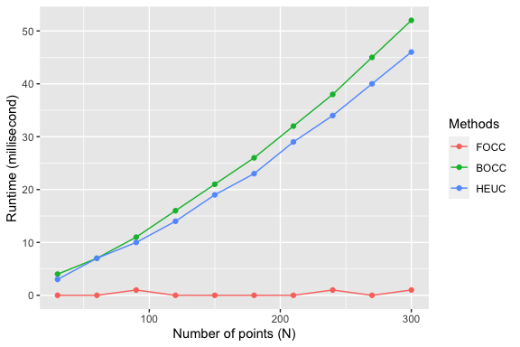

## Runtime as a function of number of clusters

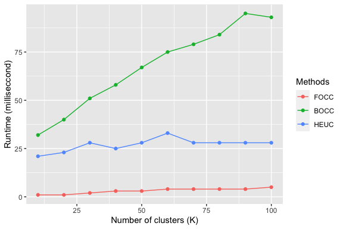

## Circular clustering optimality as a function of number of clusters

The within-cluster sum of squared distances (SSQ) indicates the compactness of a cluster. A low value of SSQ suggests a good compact clustering outcome. The last figure shows the change in SSQ value with number of clusters $K$ in the data. The SSQ values of BOCC and FOCC always remain no more than that of the HEUC algorithm. This indicates the optimal BOCC and FOCC algorithms identify better clusters than the heuristic HEUC algorithm. The advantage of FOCC and BOCC over HEUC in SSQ gradually increases with $K$.

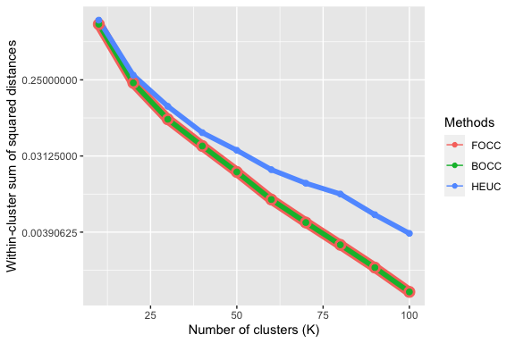

## References

Debnath, Tathagata, and Mingzhou Song. 2021. “Fast Optimal Circular Clustering and Applications on Round Genomes.” *IEEE/ACM Transactions on Computational Biology and Bioinformatics*. https://doi.org/10.1109/TCBB.2021.3077573.